# weather_classification

#### checking the distribution of some features

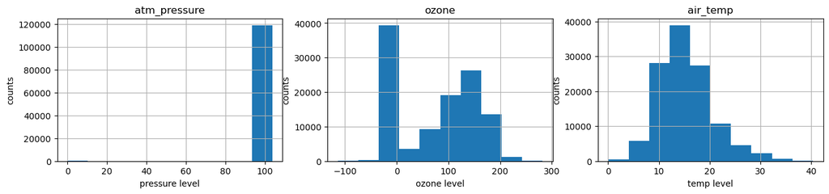

```python
#trying to check the distribution of
plt.figure(figsize=(16,3))
plt.subplot(1,3,1)
cleaned_df['atm_pressure'].hist()
plt.title('atm_pressure')
plt.ylabel('counts')
plt.xlabel('pressure level')

plt.subplot(1,3,2)
cleaned_df['ozone'].hist()
plt.title('ozone')
plt.ylabel('counts')
plt.xlabel('ozone level')

plt.subplot(1,3,3)
cleaned_df['air_temp'].hist()
plt.title('air_temp')
plt.ylabel('counts')
plt.xlabel('temp level')
```

```python
#####fillin up the nan with the their median
for column in cleaned_df:
    if pd.api.types.is_numeric_dtype(cleaned_df[column]):
        cleaned_df[column].fillna(cleaned_df[column].median(), inplace=True)

# Display the DataFrame after filling NA with median
cleaned_df.head()
```

|  | time_1 | lat_long_1 | rtc | battery | solarpanel | command | solar | precipitation | strikes | avg_wind_speed | ... | ozone | particulateserr | particulatesvsn | peakspl | pm1 | pm10 | pm25 | temperature | vbatt | vpanel |
| --- | --- | --- | --- | --- | --- | --- | --- | --- | --- | --- | --- | --- | --- | --- | --- | --- | --- | --- | --- | --- | --- |
| 0 | 2021-05-14T18:11:23+00:00 | -37.8022141, 144.9656262 | 10090042.0 | 4.161 | 0.024 | 0.0 | 0.0 | 0.0 | 0.0 | 4.09 | ... | 137.0 | 0.0 | 151.0 | 69.0 | 12.0 | 19.0 | 17.0 | 12.3 | 3.96 | 0.00 |
| 1 | 2022-05-03T10:25:31+00:00 | -37.8022141, 144.9656262 | 17564045.0 | 4.181 | 0.000 | 0.0 | 0.0 | 0.0 | 0.0 | 0.54 | ... | 156.0 | 0.0 | 151.0 | 62.0 | 15.0 | 24.0 | 22.0 | 10.9 | 3.93 | 0.00 |
| 2 | 2022-05-03T21:42:23+00:00 | -37.8022141, 144.9656262 | 17604657.0 | 4.143 | 20.670 | 0.0 | 24.0 | 0.0 | 0.0 | 0.76 | ... | 137.0 | 0.0 | 151.0 | 64.0 | 0.0 | 0.0 | 0.0 | 15.1 | 3.76 | 16.33 |
| 3 | 2022-05-04T00:42:43+00:00 | -37.8022141, 144.9656262 | 17615477.0 | 4.208 | 20.694 | 0.0 | 68.0 | 0.0 | 0.0 | 1.01 | ... | 156.0 | 0.0 | 151.0 | 68.0 | 19.0 | 29.0 | 24.0 | 10.5 | 3.92 | 0.00 |
| 4 | 2021-05-15T07:55:22+00:00 | -37.8022141, 144.9656262 | 10139481.0 | 4.197 | 0.128 | 0.0 | 0.0 | 0.0 | 0.0 | 2.66 | ... | 119.0 | 0.0 | 151.0 | 62.0 | 0.0 | 0.0 | 0.0 | 14.9 | 4.01 | 18.33 |

5 rows × 30 columns

```python
cleaned_df.columns
```

```
Index(['time_1', 'lat_long_1', 'rtc', 'battery', 'solarpanel', 'command',
       'solar', 'precipitation', 'strikes', 'avg_wind_speed',
       'avg_wind_direction', 'gust_wind_speed', 'vapourpressure',
       'atm_pressure', 'air_temp', 'averagespl', 'carbonmonoxide',
       'humidity_1', 'ibatt', 'nitrogendioxide', 'ozone', 'particulateserr',
       'particulatesvsn', 'peakspl', 'pm1', 'pm10', 'pm25', 'temperature',
       'vbatt', 'vpanel'],
      dtype='object')
```

```python
cleaned_df.isna().sum()*100/len(cleaned_df)
```

```
time_1                0.000000
lat_long_1            2.196477
rtc                   0.000000
battery               0.000000
solarpanel            0.000000
command               0.000000
solar                 0.000000
precipitation         0.000000
strikes               0.000000
avg_wind_speed        0.000000
avg_wind_direction    0.000000
gust_wind_speed       0.000000
vapourpressure        0.000000
atm_pressure          0.000000
air_temp              0.000000
averagespl            0.000000
carbonmonoxide        0.000000
humidity_1            0.000000
ibatt                 0.000000
nitrogendioxide       0.000000
ozone                 0.000000
particulateserr       0.000000
particulatesvsn       0.000000
peakspl               0.000000
pm1                   0.000000
pm10                  0.000000
pm25                  0.000000
temperature           0.000000
vbatt                 0.000000
vpanel                0.000000
dtype: float64
```

```python
cleaned_df['lat_long_1'] = cleaned_df['lat_long_1'].fillna(cleaned_df['lat_long_1'].mode())
```

```python
mode_value = cleaned_df['lat_long_1'].mode()[0]

cleaned_df['lat_long_1'] = cleaned_df['lat_long_1'].fillna(mode_value)
```

```python
cleaned_df.isna().sum()*100/len(cleaned_df)
```

```
time_1                0.0
lat_long_1            0.0
rtc                   0.0
battery               0.0
solarpanel            0.0
command               0.0
solar                 0.0
precipitation         0.0
strikes               0.0
avg_wind_speed        0.0
avg_wind_direction    0.0
gust_wind_speed       0.0
vapourpressure        0.0
atm_pressure          0.0
air_temp              0.0
averagespl            0.0
carbonmonoxide        0.0
humidity_1            0.0
ibatt                 0.0
nitrogendioxide       0.0
ozone                 0.0
particulateserr       0.0
particulatesvsn       0.0
peakspl               0.0
pm1                   0.0
pm10                  0.0
pm25                  0.0
temperature           0.0
vbatt                 0.0
vpanel                0.0
dtype: float64
```

```python
cleaned_df.tail()
```

|  | time_1 | lat_long_1 | rtc | battery | solarpanel | command | solar | precipitation | strikes | avg_wind_speed | ... | ozone | particulateserr | particulatesvsn | peakspl | pm1 | pm10 | pm25 | temperature | vbatt | vpanel |
| --- | --- | --- | --- | --- | --- | --- | --- | --- | --- | --- | --- | --- | --- | --- | --- | --- | --- | --- | --- | --- | --- |
| 121872 | 2024-08-30T11:49:22+00:00 | -37.8022141, 144.9656262 | 91008761.0 | 4.171 | 0.225 | 0.0 | 0.0 | 0.0 | 0.0 | 0.88 | ... | 91.0 | 0.0 | 151.0 | 69.0 | 1.0 | 2.0 | 1.0 | 15.5 | 3.86 | 16.41 |
| 121873 | 2024-08-30T12:04:08+00:00 | -37.8022141, 144.9656262 | 91009640.0 | 4.172 | 0.225 | 0.0 | 0.0 | 0.0 | 0.0 | 1.00 | ... | 13.0 | 0.0 | 151.0 | 77.0 | 5.0 | 6.0 | 6.0 | 31.1 | 3.99 | 18.39 |
| 121874 | 2024-08-30T12:49:09+00:00 | -37.8022141, 144.9656262 | 91012348.0 | 4.168 | 0.217 | 0.0 | 0.0 | 0.0 | 0.0 | 1.16 | ... | 137.0 | 0.0 | 151.0 | 64.0 | 0.0 | 0.0 | 0.0 | 16.6 | 3.89 | 0.00 |
| 121875 | 2024-08-30T13:19:06+00:00 | -37.8022141, 144.9656262 | 91014145.0 | 4.165 | 0.225 | 0.0 | 0.0 | 0.0 | 0.0 | 1.58 | ... | 13.0 | 0.0 | 151.0 | 79.0 | 7.0 | 10.0 | 9.0 | 30.4 | 3.99 | 18.37 |
| 121876 | 2024-08-30T14:32:54+00:00 | -37.8022141, 144.9656262 | 91018573.0 | 4.162 | 0.225 | 0.0 | 0.0 | 0.0 | 0.0 | 1.15 | ... | 124.0 | 0.0 | 151.0 | 62.0 | 0.0 | 1.0 | 0.0 | 16.3 | 3.89 | 0.00 |

5 rows × 30 columns

##### ANalysis

```python
cleaned_df.describe()
```

|  | rtc | battery | solarpanel | command | solar | precipitation | strikes | avg_wind_speed | avg_wind_direction | gust_wind_speed | ... | ozone | particulateserr | particulatesvsn | peakspl | pm1 | pm10 | pm25 | temperature | vbatt | vpanel |
| --- | --- | --- | --- | --- | --- | --- | --- | --- | --- | --- | --- | --- | --- | --- | --- | --- | --- | --- | --- | --- | --- |
| count | 1.218770e+05 | 121877.000000 | 121877.000000 | 121877.0 | 121877.000000 | 121877.000000 | 121877.000000 | 121877.000000 | 121877.000000 | 121877.000000 | ... | 121877.000000 | 121877.000000 | 121877.000000 | 121877.000000 | 121877.000000 | 121877.000000 | 121877.000000 | 121877.000000 | 121877.000000 | 121877.000000 |
| mean | 3.826837e+07 | 4.176773 | 10.495417 | 0.0 | 120.103842 | 0.000025 | 0.003339 | -4.224586 | 161.404079 | -2.263293 | ... | 76.448961 | 0.001452 | 146.821082 | 69.944428 | 3.101184 | 5.545944 | 4.558580 | 16.096777 | 3.861539 | 12.897769 |
| std | 4.148414e+07 | 0.117541 | 10.079715 | 0.0 | 205.548106 | 0.006405 | 0.181879 | 230.880824 | 247.868019 | 230.933901 | ... | 73.457100 | 0.507005 | 24.769898 | 7.706349 | 5.908866 | 9.877775 | 49.327864 | 5.130164 | 0.102387 | 11.029032 |
| min | 1.900000e+01 | 0.308000 | 0.000000 | 0.0 | 0.000000 | 0.000000 | 0.000000 | -9999.000000 | -9999.000000 | -9999.000000 | ... | -114.000000 | 0.000000 | 0.000000 | 55.000000 | 0.000000 | 0.000000 | 0.000000 | 2.000000 | 0.580000 | 0.000000 |
| 25% | 1.364448e+07 | 4.158000 | 0.032000 | 0.0 | 0.000000 | 0.000000 | 0.000000 | 0.710000 | 135.500000 | 1.730000 | ... | -13.000000 | 0.000000 | 151.000000 | 63.000000 | 0.000000 | 1.000000 | 0.000000 | 12.600000 | 3.810000 | 0.000000 |
| 50% | 3.178422e+07 | 4.181000 | 11.604000 | 0.0 | 2.000000 | 0.000000 | 0.000000 | 0.980000 | 176.800000 | 2.640000 | ... | 91.000000 | 0.000000 | 151.000000 | 69.000000 | 1.000000 | 2.000000 | 1.000000 | 15.500000 | 3.860000 | 16.410000 |
| 75% | 6.042885e+07 | 4.206000 | 21.411000 | 0.0 | 157.000000 | 0.000000 | 0.000000 | 1.350000 | 197.300000 | 3.890000 | ... | 137.000000 | 0.000000 | 151.000000 | 75.000000 | 3.000000 | 6.000000 | 4.000000 | 18.800000 | 3.930000 | 21.690000 |
| max | 1.100097e+09 | 4.232000 | 23.877000 | 0.0 | 1088.000000 | 2.000000 | 42.000000 | 6.050000 | 360.000000 | 161.000000 | ... | 282.000000 | 177.000000 | 151.000000 | 109.000000 | 120.000000 | 251.000000 | 16973.000000 | 41.400000 | 4.040000 | 30.080000 |

8 rows × 28 columns

#### Variation od Avg_Wind_speed and Gust_Wind_speed

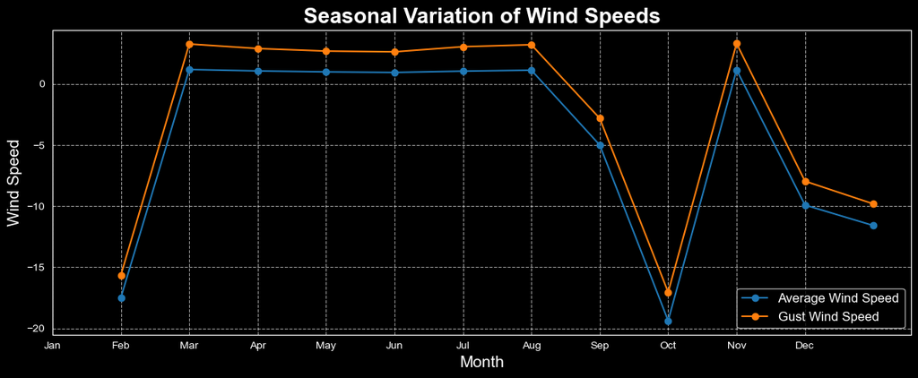

```python
# Convert 'time_1' to datetime
cleaned_df['time_1'] = pd.to_datetime(cleaned_df['time_1'])

# Extract the month
cleaned_df['month'] = cleaned_df['time_1'].dt.month

# Calculate monthly means
monthly_avg = cleaned_df.groupby('month')[['avg_wind_speed', 'gust_wind_speed']].mean()

# Ensure all months are represented, even if some months might not have data
all_months = pd.DataFrame({'month': np.arange(1, 13)})
monthly_avg = all_months.merge(monthly_avg, on='month', how='left').set_index('month')

# Set the background style to dark
sns.set_style('darkgrid')
plt.style.use('dark_background')

# Plot monthly means
plt.figure(figsize=(12, 5))
ax = monthly_avg.plot(kind='line', marker='o', linestyle='-', ax=plt.gca(), color=['#1f77b4', '#ff7f0e'])
plt.title('Seasonal Variation of Wind Speeds', fontsize=20, fontweight='bold', color='white')
plt.xlabel('Month', fontsize=15, color='white')
plt.ylabel('Wind Speed', fontsize=15, color='white')
plt.xticks(ticks=np.arange(12), labels=['Jan', 'Feb', 'Mar', 'Apr', 'May', 'Jun', 'Jul', 'Aug', 'Sep', 'Oct', 'Nov', 'Dec'], color='white')
plt.yticks(color='white')
plt.legend(['Average Wind Speed', 'Gust Wind Speed'], fontsize=12)

# Customize the plot appearance
ax.spines['bottom'].set_color('white')
ax.spines['left'].set_color('white')
ax.tick_params(colors='white')
ax.grid(True, linestyle='--', alpha=0.6)

plt.tight_layout()
plt.show()
```

#### Impact of Vapour Pressure on Humidity

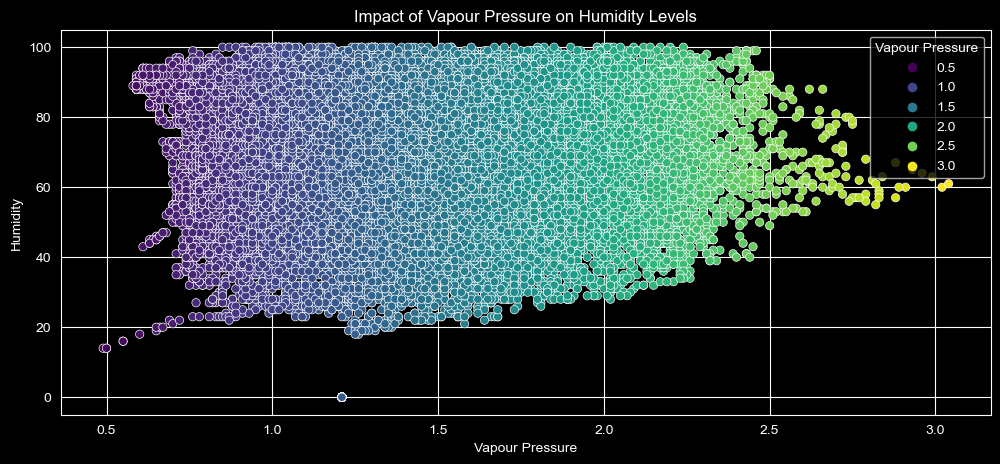

```python
# Set up the plotting area
plt.figure(figsize=(12, 5))
plt.style.use('dark_background')

# Create scatter plot with a gradient based on density
sns.scatterplot(x='vapourpressure', y='humidity_1', data=cleaned_df, hue='vapourpressure', palette='viridis')

# Set plot title and labels
plt.title('Impact of Vapour Pressure on Humidity Levels', color='white')
plt.xlabel('Vapour Pressure', color='white')
plt.ylabel('Humidity', color='white')
plt.legend(title='Vapour Pressure', loc='upper right')

# Show the plot
plt.show()
```

#### Patterns in Air Temperature, Humidity, and Pressure

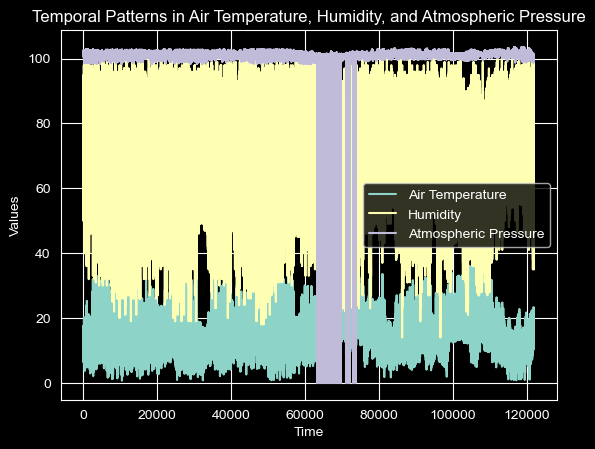

```python
plt.figure(figsize=(12, 6))
cleaned_df[['air_temp', 'humidity_1', 'atm_pressure']].plot()
plt.title('Temporal Patterns in Air Temperature, Humidity, and Atmospheric Pressure')
plt.xlabel('Time')
plt.ylabel('Values')
plt.legend(['Air Temperature', 'Humidity', 'Atmospheric Pressure'])
plt.show()
```

The graph shows how air temperature, humidity, and atmospheric pressure change over time. The high and consistent levels of humidity suggest that the environment remains moist throughout the recorded period. Humidity levels stay quite high most of the time, which indicates a steady moisture presence, possibly due to frequent rainfall or high moisture in the air. This moisture could have a significant impact on local weather conditions and daily life.

The air temperature fluctuates noticeably, showing frequent rises and falls. This pattern suggests regular cycles in temperature, likely driven by daily weather changes or seasonal effects. These temperature changes are typical of environments where temperatures shift between day and night or during different seasons.